# MOFA+ CLL Analysis - Simplified Pipeline

Based on MOFA2 Tutorial by Ricard Argelaguet and Britta Velten

2025-12-13

# Introduction

This vignette demonstrates MOFA+ (Multi-Omics Factor Analysis) on a CLL (Chronic Lymphocytic Leukemia) multi-omics dataset. The data consists of four omics:

- **DNA methylation** (4248 features)
- **RNA-seq / mRNA** (5000 features)
- **Somatic mutations** (69 features)
- **Drug response** (310 features)

from N=200 patients with CLL.

**Key approach**: We load a pre-trained model to avoid Python/R compatibility issues, then focus on analysis and interpretation.

# 1. Load Libraries and Data

```r
library(MOFA2)
library(MOFAdata)
library(data.table)
library(ggplot2)
library(tidyverse)

cat("✓ Libraries loaded successfully!\n")
```

```
## ✓ Libraries loaded successfully!
```

## Load the CLL Data

```r
# Load the multi-omics data
utils::data("CLL_data")

# Examine structure
cat("=== CLL Data Structure ===\n")
```

```
## === CLL Data Structure ===
```

```r
cat("Number of omics modalities:", length(CLL_data), "\n")
```

```
## Number of omics modalities: 4
```

```r
cat("Modality names:", paste(names(CLL_data), collapse=", "), "\n\n")
```

```
## Modality names: Drugs, Methylation, mRNA, Mutations
```

```r
# Dimensions
lapply(CLL_data, dim)
```

```
## $Drugs
## [1] 310 200
##
## $Methylation
## [1] 4248  200
##
## $mRNA
## [1] 5000  200
##
## $Mutations
## [1]  69 200
```

## Load Sample Metadata

```r
# Load metadata from MOFA repository
CLL_metadata <- tryCatch({
  fread("ftp://ftp.ebi.ac.uk/pub/databases/mofa/cll_vignette/sample_metadata.txt")
}, error = function(e) {
  cat("Could not load metadata from FTP. Creating minimal metadata...\n")
  data.frame(sample = colnames(CLL_data$mRNA))
})

cat("Metadata dimensions:", nrow(CLL_metadata), "samples,", ncol(CLL_metadata), "variables\n")
```

```
## Metadata dimensions: 200 samples, 9 variables
```

```r
if (ncol(CLL_metadata) > 1) {
  cat("Clinical variables:", paste(colnames(CLL_metadata), collapse=", "), "\n")
}
```

```
## Clinical variables: sample, Gender, age, TTT, TTD, treatedAfter, died, IGHV, trisomy12
```

```r
head(CLL_metadata)
```

```
##    sample Gender      age        TTT      TTD treatedAfter   died  IGHV
##    <char> <char>    <num>      <num>    <num>       <lgcl> <lgcl> <int>
## 1:   H005      m 75.26575 0.57494867 2.625599         TRUE  FALSE     1
## 2:   H006      m       NA         NA       NA           NA     NA    NA
## 3:   H007      f       NA         NA       NA           NA     NA    NA
## 4:   H008      m       NA         NA       NA           NA     NA    NA
## 5:   H010      f 72.78082 2.93223819 2.932238        FALSE  FALSE     0
## 6:   H011      f 72.99452 0.01916496 2.951403         TRUE  FALSE     1
##    trisomy12
##        <int>
## 1:         0
## 2:        NA
## 3:        NA
## 4:        NA
## 5:         0
## 6:         0
```

# 2. Load Pre-trained MOFA Model

The original tutorial provides a pre-trained model. This approach: - Avoids Python/mofapy2 compatibility issues - Guarantees reproducibility - Allows immediate analysis

```r
cat("=== Loading Pre-trained MOFA Model ===\n")
```

```
## === Loading Pre-trained MOFA Model ===
```

```r
cat("Downloading from EBI FTP...\n\n")
# Load the pre-trained model from the official repository
MOFAobject <- readRDS(url("http://ftp.ebi.ac.uk/pub/databases/mofa/cll_vignette/MOFA2_CLL.rds"))

cat("✓ Model loaded successfully!\n\n")
```

```
## ✓ Model loaded successfully!
```

```r
# Display model summary
print(MOFAobject)
```

```
## Trained MOFA with the following characteristics:
##  Number of views: 4
##  Views names: Drugs Methylation mRNA Mutations
##  Number of features (per view): 310 4248 5000 69
##  Number of groups: 1
##  Groups names: group1
##  Number of samples (per group): 200
##  Number of factors: 15
```

## Add Sample Metadata to Model

```r
# Add clinical metadata to the MOFA object
samples_metadata(MOFAobject) <- CLL_metadata

cat("✓ Metadata added to model\n")
```

```
## ✓ Metadata added to model
```

```r
cat("Available covariates:", paste(colnames(samples_metadata(MOFAobject)), collapse=", "), "\n")
```

```
## Available covariates: sample, Gender, age, TTT, TTD, treatedAfter, died, IGHV, trisomy12, group
```

# 3. Overview of the Trained Model

## Model Slots

```r
# Key slots in the MOFA object
cat("=== MOFA Object Slots ===\n")
```

```
## === MOFA Object Slots ===
```

```r
slotNames(MOFAobject)
```

```
##  [1] "data"               "covariates"         "covariates_warped"
##  [4] "intercepts"         "imputed_data"       "interpolated_Z"
##  [7] "samples_metadata"   "features_metadata"  "expectations"
## [10] "training_stats"     "data_options"       "model_options"
## [13] "training_options"   "stochastic_options" "mefisto_options"
## [16] "dimensions"         "on_disk"            "dim_red"
## [19] "cache"              "status"
```

## Data Dimensions

```r
# Views (data modalities)
cat("\n=== Data Views ===\n")
```

```
##
## === Data Views ===
```

```r
names(MOFAobject@data)
```

```
## [1] "Drugs"       "Methylation" "mRNA"        "Mutations"
```

```r
# Dimensions of each view
cat("\nDrugs view:", dim(MOFAobject@data$Drugs$group1), "\n")
```

```
##
## Drugs view: 310 200
```

```r
cat("mRNA view:", dim(MOFAobject@data$mRNA$group1), "\n")
```

```
## mRNA view: 5000 200
```

## Factor and Weight Matrices

```r
# Factor matrix: samples x factors
cat("=== Factor Matrix ===\n")
```

```
## === Factor Matrix ===
```

```r
cat("Dimensions:", dim(MOFAobject@expectations$Z$group1), "(samples x factors)\n")
```

```
## Dimensions: 200 15 (samples x factors)
```

```r
# Weight matrices: features x factors
cat("\n=== Weight Matrices ===\n")
```

```
##
## === Weight Matrices ===
```

```r
cat("mRNA weights:", dim(MOFAobject@expectations$W$mRNA), "(features x factors)\n")
```

```
## mRNA weights: 5000 15 (features x factors)
```

```r
cat("Drug weights:", dim(MOFAobject@expectations$W$Drugs), "(features x factors)\n")
```

```
## Drug weights: 310 15 (features x factors)
```

# 4. Variance Decomposition

The most important insight from MOFA is understanding which factors explain variance in which data modalities.

## Variance Explained per Factor

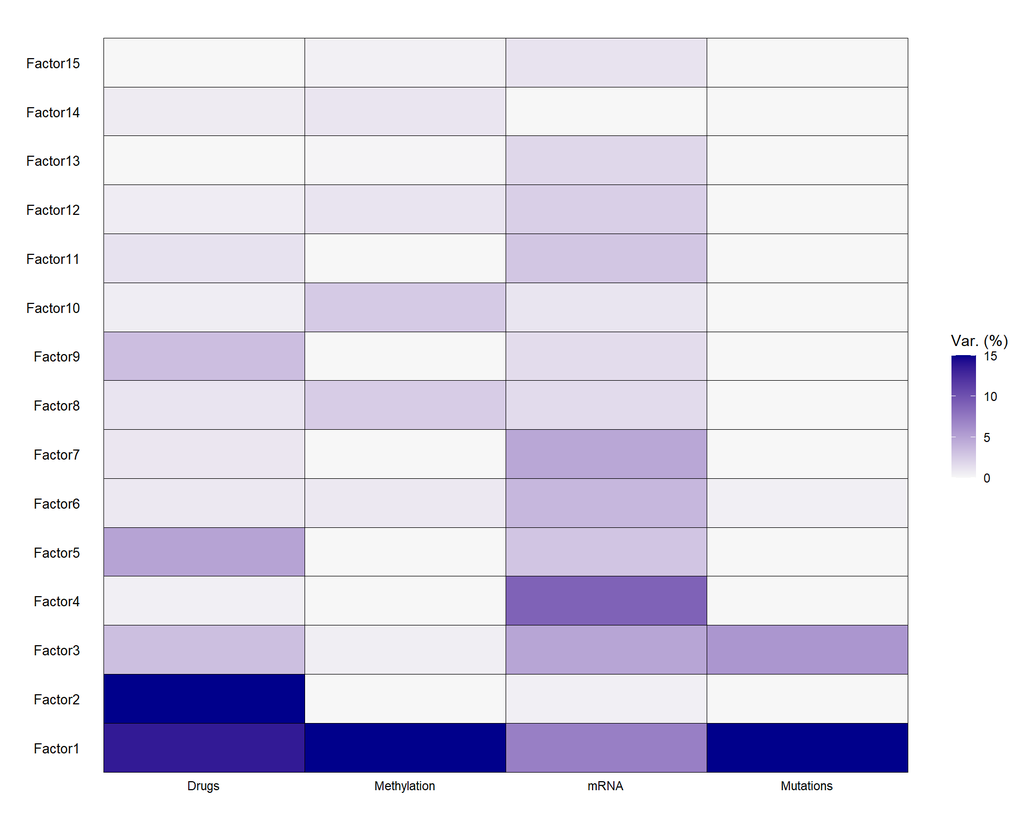

```r
plot_variance_explained(MOFAobject, max_r2 = 15)
```

**Key insights:** - Factor 1 captures variation across ALL modalities → important disease driver - Factor 2 is specific to drug response - Factor 3 captures variation in multiple modalities except methylation

## Total Variance Explained

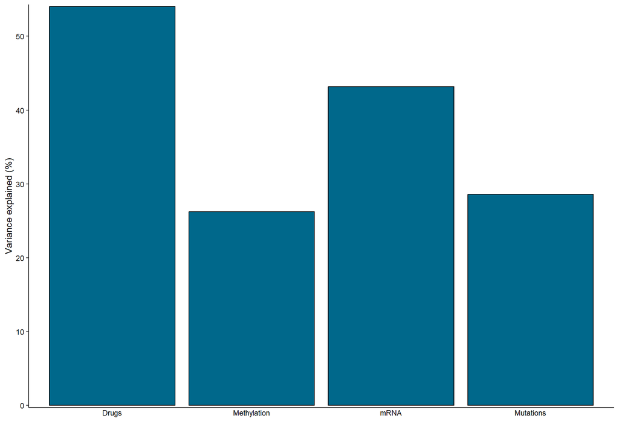

```r
plot_variance_explained(MOFAobject, plot_total = TRUE)[[2]]
```

# 5. Factor Correlation

Good models should have largely uncorrelated factors.

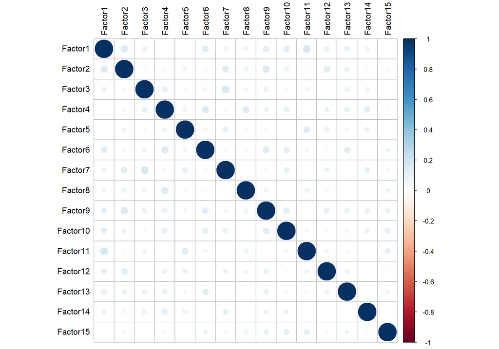

```r
plot_factor_cor(MOFAobject)
```

# 6. Characterization of Factor 1 (IGHV Mutation)

## Association with Clinical Covariates

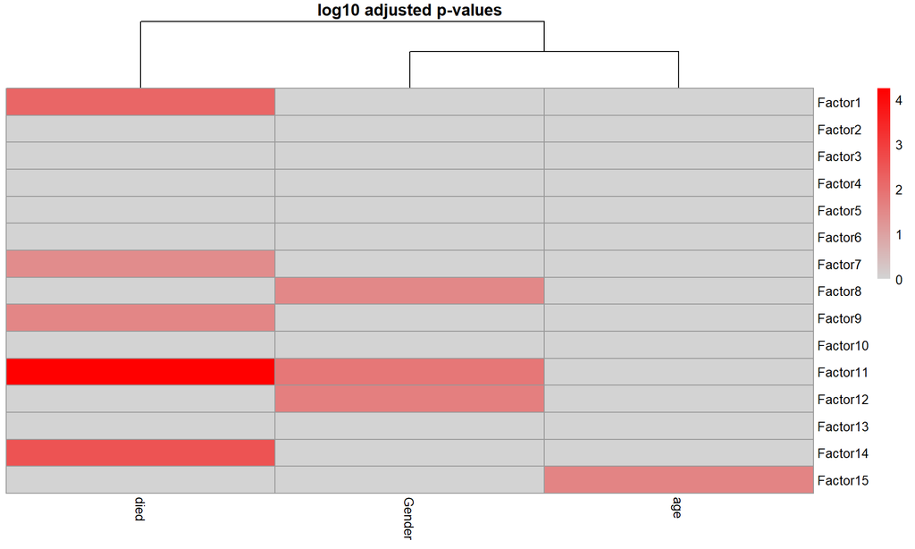

```r
correlate_factors_with_covariates(MOFAobject,
  covariates = c("Gender", "died", "age"),
  plot = "log_pval"
)
```

## Plot Factor 1 Values

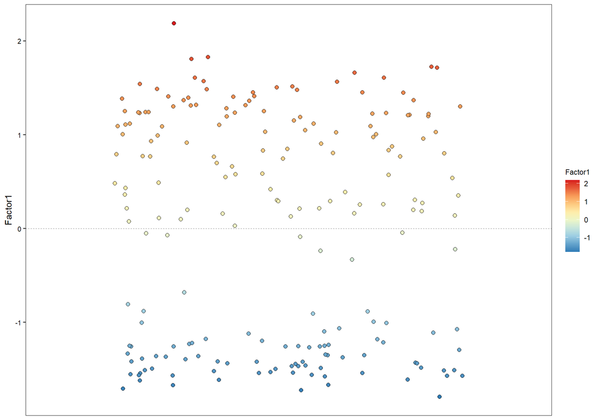

```r
plot_factor(MOFAobject,
  factors = 1,
  color_by = "Factor1"
)
```

## Feature Weights for Mutations View

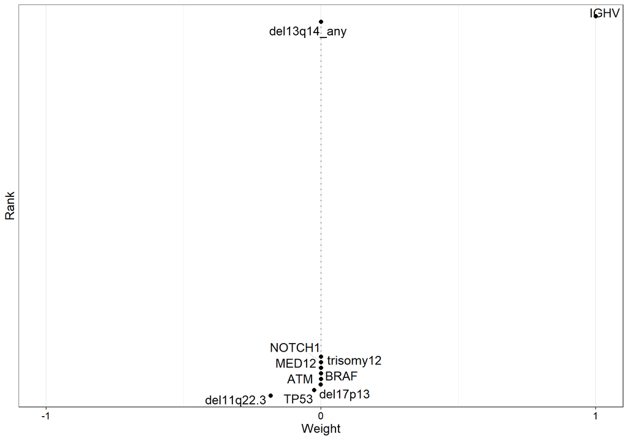

```r
plot_weights(MOFAobject,
  view = "Mutations",
  factor = 1,
  nfeatures = 10,
  abs = FALSE
)
```

**Key finding:** IGHV mutation status has the largest weight for Factor 1!

## Visualize IGHV Status

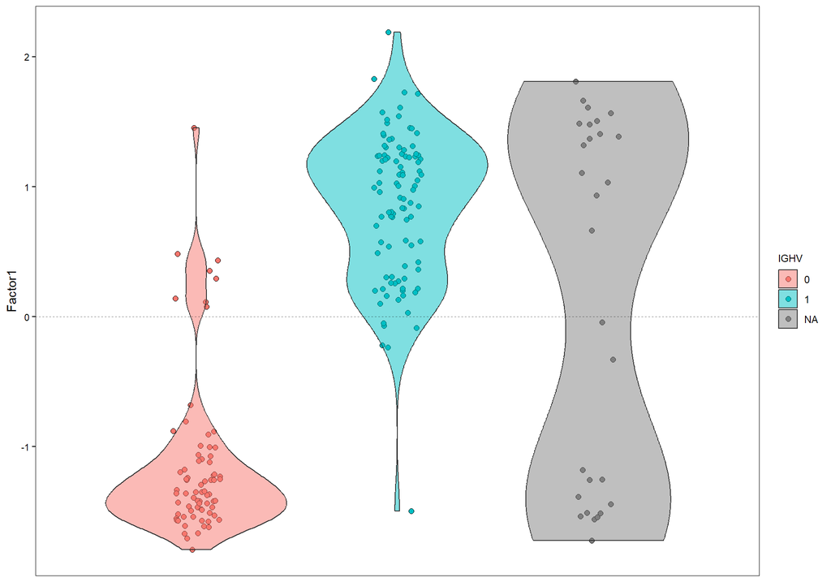

```r
plot_factor(MOFAobject,
  factors = 1,
  color_by = "IGHV",
  dodge = TRUE,
  add_violin = TRUE
)
```

## mRNA Expression Weights

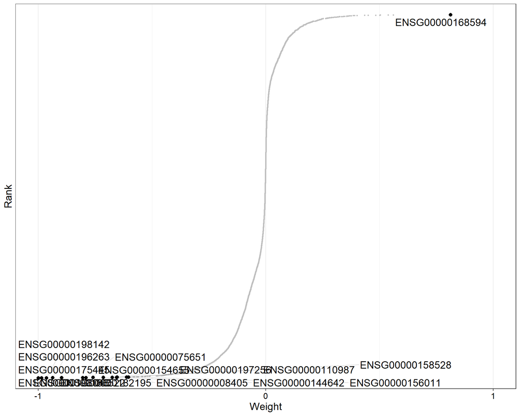

```r
plot_weights(MOFAobject,
  view = "mRNA",
  factor = 1,
  nfeatures = 15,
  abs = FALSE
)
```

## Gene Expression Heatmap

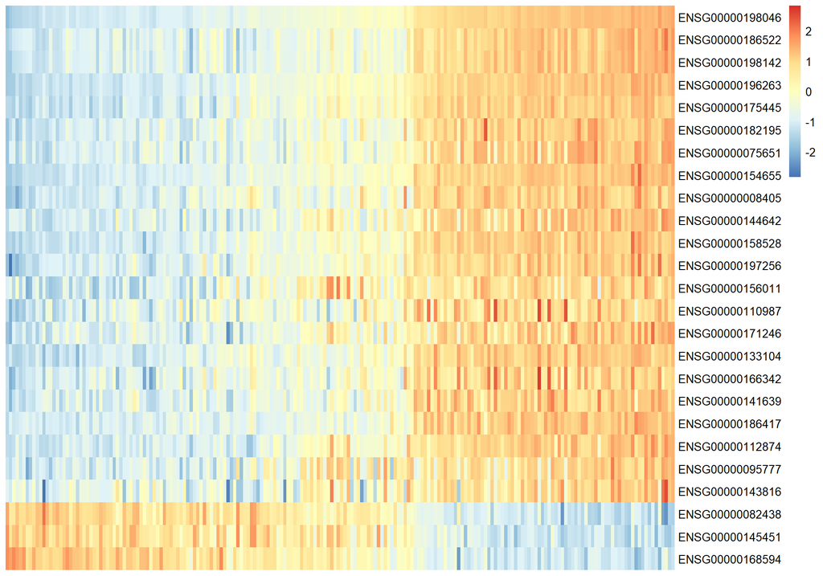

```r
plot_data_heatmap(MOFAobject,
  view = "mRNA",
  factor = 1,
  features = 25,
  denoise = TRUE,
  cluster_rows = FALSE, cluster_cols = FALSE,
  show_rownames = TRUE, show_colnames = FALSE,
  scale = "row"
)
```

# 7. Characterization of Factor 3 (Trisomy 12)

## Mutation Weights

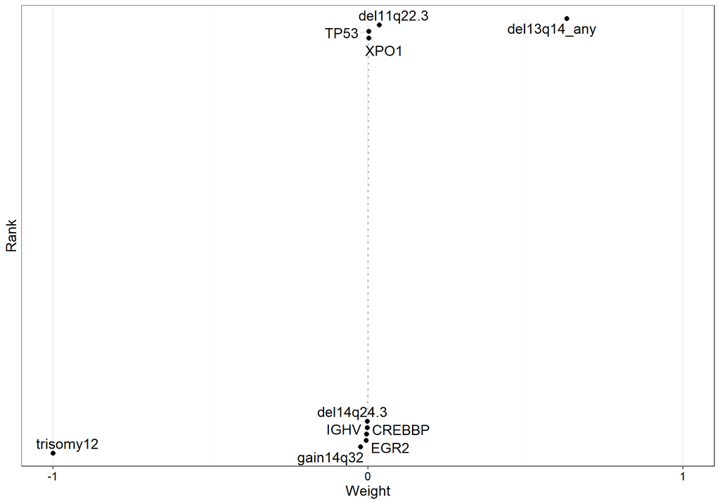

```r
plot_weights(MOFAobject,
  view = "Mutations",
  factor = 3,
  nfeatures = 10,
  abs = FALSE
)
```

**Key finding:** Trisomy 12 is the major driver of Factor 3!

## Factor Values by Trisomy 12

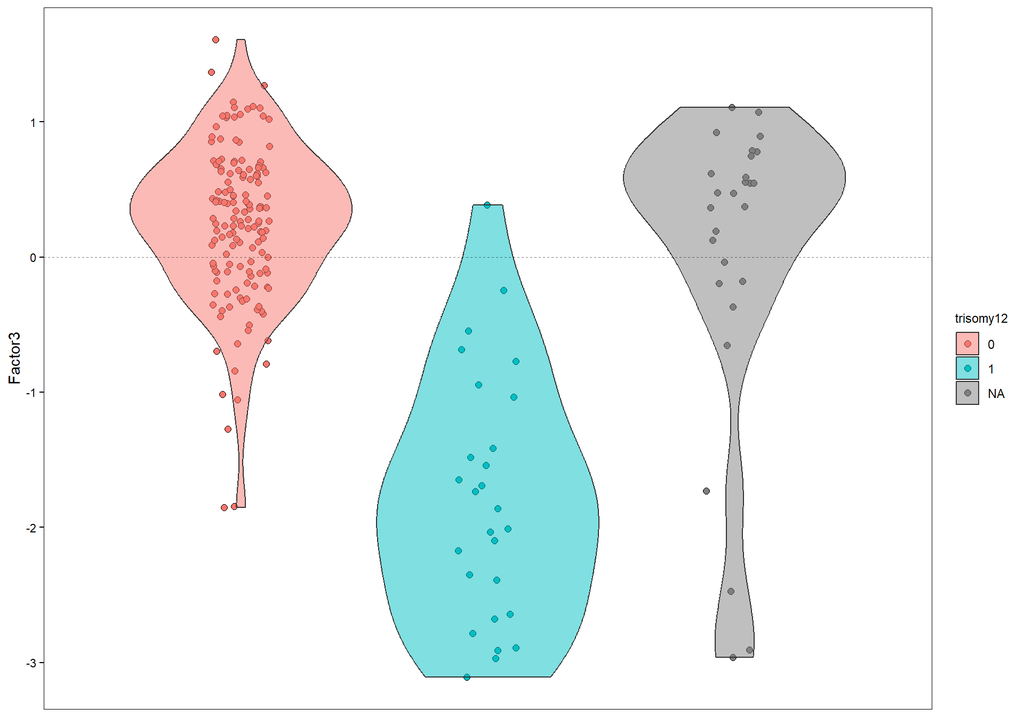

```r
plot_factor(MOFAobject,
  factors = 3,
  color_by = "trisomy12",
  dodge = TRUE,
  add_violin = TRUE
)
```

## Drug Response Signatures

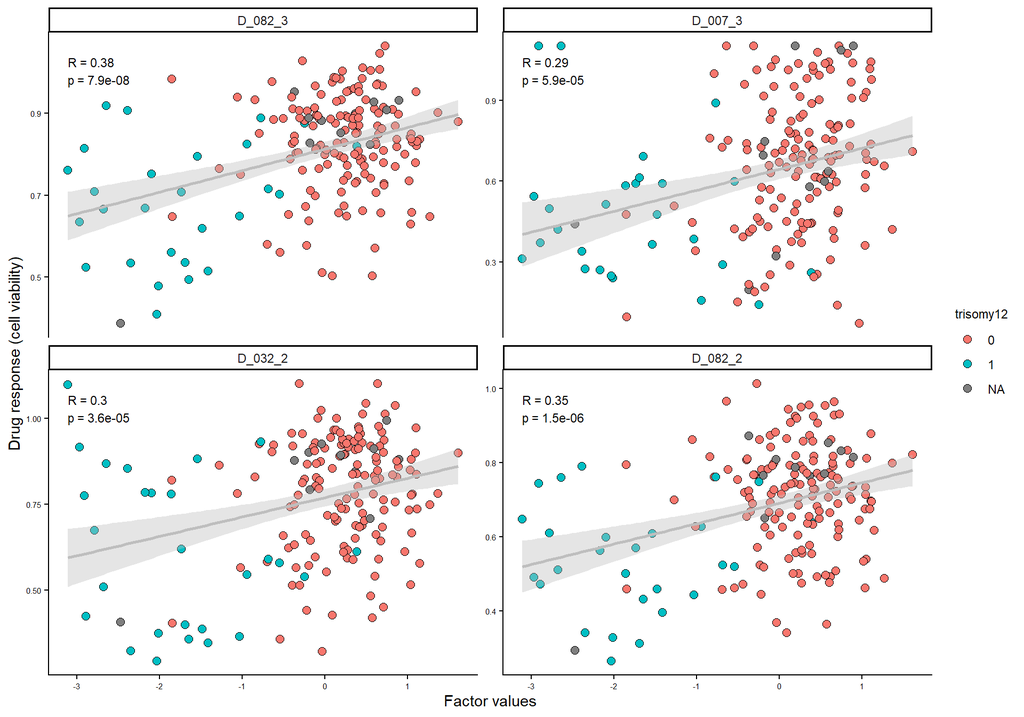

```r
plot_data_scatter(MOFAobject,
  view = "Drugs",
  factor = 3,
  features = 4,
  sign = "positive",
  color_by = "trisomy12"
) + labs(y = "Drug response (cell viability)")
```

# 8. Combined Analysis: Factor 1 vs Factor 3

This plot classifies patients into clinical subgroups based on their multi-omic profiles.

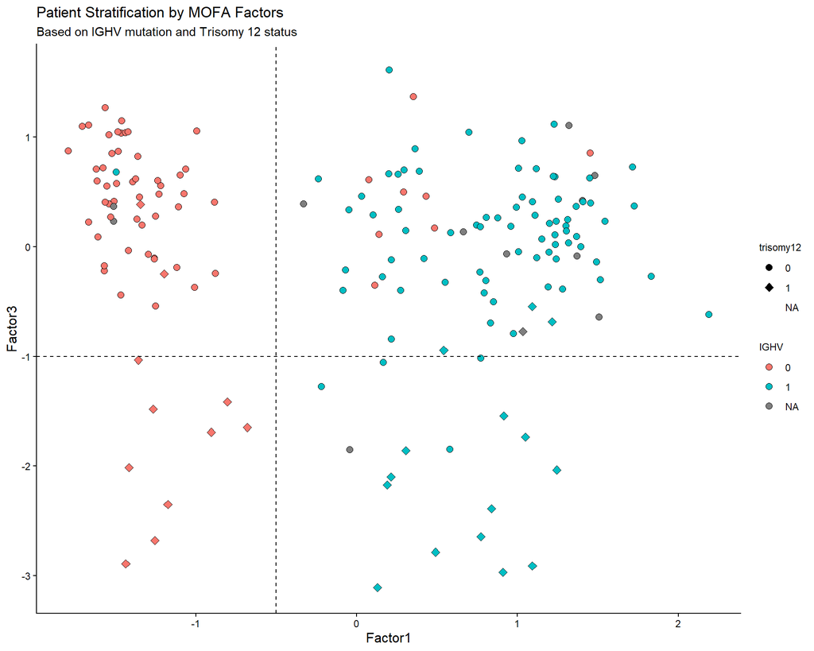

```r
p <- plot_factors(MOFAobject,
  factors = c(1, 3),
  color_by = "IGHV",
  shape_by = "trisomy12",
  dot_size = 2.5,
  show_missing = TRUE
)

p <- p +
  geom_hline(yintercept = -1, linetype = "dashed") +
  geom_vline(xintercept = -0.5, linetype = "dashed") +
  labs(title = "Patient Stratification by MOFA Factors",
       subtitle = "Based on IGHV mutation and Trisomy 12 status")

print(p)
```

# 9. Gene Set Enrichment Analysis (GSEA)

```r
# Load Reactome gene sets from MOFAdata
utils::data(reactomeGS)

cat("Gene sets:", nrow(reactomeGS), "\n")
```

```
## Gene sets: 1304
```

```r
cat("Genes covered:", ncol(reactomeGS), "\n")
```

```
## Genes covered: 18818
```

```r
cat("\nExample pathways:\n")
```

```
##
## Example pathways:
```

```r
head(rownames(reactomeGS))
```

```
## [1] "Interleukin-6 signaling"
## [2] "Apoptosis"
## [3] "Hemostasis"
## [4] "Intrinsic Pathway for Apoptosis"
## [5] "Cleavage of Growing Transcript in the Termination Region "
## [6] "PKB-mediated events"
```

## Run GSEA

```r
# Run enrichment analysis on Factor 1
enrichment_results <- run_enrichment(MOFAobject,
  feature.sets = reactomeGS,
  view = "mRNA",
  factors = 1:5,
  set.statistic = "mean.diff",
  statistical.test = "parametric"
)
```

## Plot Enrichment Results

```r
# Plot enrichment results (with error handling for no significant pathways)
tryCatch({
  plot_enrichment(enrichment_results,
    factor = 1,
    max.pathways = 15,
    alpha = 0.1  # Relaxed threshold for demonstration
  )
}, error = function(e) {
  cat("Note: No significant pathways at default threshold.\n")
  cat("Showing top pathways regardless of significance:\n")
  # Display top results manually
  results_df <- enrichment_results$pval.adj[, 1, drop = FALSE]
  results_df <- data.frame(pathway = rownames(results_df), pval_adj = results_df[,1])
  results_df <- results_df[order(results_df$pval_adj), ]
  print(head(results_df, 15))
})
```

```
## Note: No significant pathways at default threshold.
## Showing top pathways regardless of significance:
##                                                                                                       pathway
## Hemostasis                                                                                         Hemostasis
## PI3K Cascade                                                                                     PI3K Cascade
## Opioid Signalling                                                                           Opioid Signalling
## G-protein mediated events                                                           G-protein mediated events
## PLC beta mediated events                                                             PLC beta mediated events
## Neurotransmitter Release Cycle                                                 Neurotransmitter Release Cycle
## IRS-mediated signalling                                                               IRS-mediated signalling
## SOS-mediated signalling                                                               SOS-mediated signalling
## Platelet degranulation                                                                Platelet degranulation
## Downstream signaling events of B Cell Receptor (BCR)     Downstream signaling events of B Cell Receptor (BCR)
## Meiotic synapsis                                                                             Meiotic synapsis
## Signaling by FGFR in disease                                                     Signaling by FGFR in disease
## Signaling by ERBB2                                                                         Signaling by ERBB2
## Erythrocytes take up carbon dioxide and release oxygen Erythrocytes take up carbon dioxide and release oxygen
## PIP3 activates AKT signaling                                                     PIP3 activates AKT signaling
##                                                        pval_adj
## Hemostasis                                             0.827778
## PI3K Cascade                                           0.827778
## Opioid Signalling                                      0.827778
## G-protein mediated events                              0.827778
## PLC beta mediated events                               0.827778
## Neurotransmitter Release Cycle                         0.827778
## IRS-mediated signalling                                0.827778
## SOS-mediated signalling                                0.827778
## Platelet degranulation                                 0.827778
## Downstream signaling events of B Cell Receptor (BCR)   0.827778
## Meiotic synapsis                                       0.827778
## Signaling by FGFR in disease                           0.827778
## Signaling by ERBB2                                     0.827778
## Erythrocytes take up carbon dioxide and release oxygen 0.827778
## PIP3 activates AKT signaling                           0.827778
```

# 10. Dimensionality Reduction

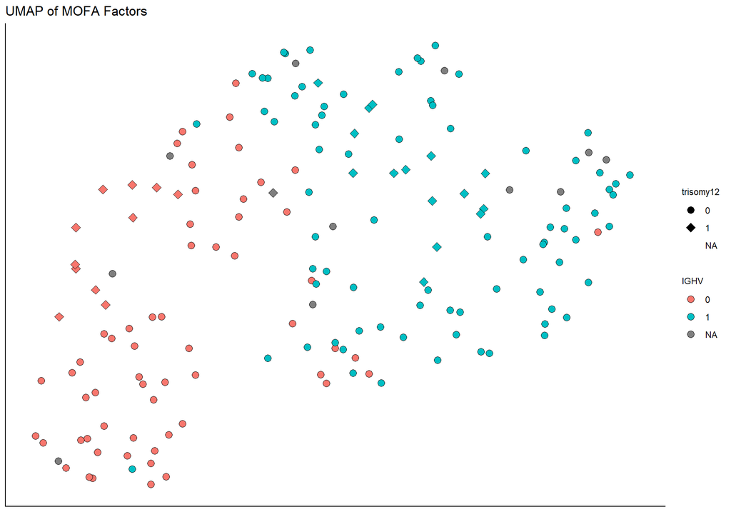

```r
# Run UMAP on MOFA factors
set.seed(42)
MOFAobject <- run_umap(MOFAobject)

# Plot UMAP colored by clinical features
plot_dimred(MOFAobject,
  method = "UMAP",
  color_by = "IGHV",
  shape_by = "trisomy12",
  dot_size = 3
) + labs(title = "UMAP of MOFA Factors")
```

# Summary

These factors can be used for: - **Predicting treatment response** - **Patient stratification** - **Biomarker discovery** - **Survival analysis**